# GSE129611 dataset

Make metadata

Audrey

2025-01-07

```r
library(dplyr)
library(patchwork)
library(ggplot2)

.libPaths()
```

```
## [1] "/usr/local/lib/R/library"
```

# Preparation

In this section, we set the global settings of the analysis. We will store data there :

```r
save_name = "takahashi"
out_dir = "."
```

# Sample info

```r
sample_info = data.frame(
  project_name = c("GSM3717034", "GSM3717035", "GSM3717036", "GSM3717037", "GSM3717038"),
  sample_type = rep("HD", 5),
  gender = c("M", "M", "M", "M", "F"),
  platform = c(rep("Drop-Seq", 3), rep("10X", 2)),
  location = rep("hair scalp", 5),
  laboratory = rep("Takahashi", 5),
  color = c("lawngreen", "palegreen3", "yellowgreen", "darkolivegreen", "forestgreen"),
  stringsAsFactors = FALSE) %>%
  dplyr::mutate(project_name = factor(project_name, levels = project_name)) %>%
  dplyr::mutate(unique_id = data.table::rowid(sample_type)) %>%
  dplyr::mutate(sample_identifier = paste0(laboratory, "_", sample_type, "_", unique_id)) %>%
  dplyr::mutate(sample_identifier = factor(sample_identifier, levels = sample_identifier)) %>%
  dplyr::select(project_name, sample_type, sample_identifier, platform, gender, location, laboratory, color)

sample_info
```

```
##   project_name sample_type sample_identifier platform gender   location
## 1   GSM3717034          HD    Takahashi_HD_1 Drop-Seq      M hair scalp
## 2   GSM3717035          HD    Takahashi_HD_2 Drop-Seq      M hair scalp
## 3   GSM3717036          HD    Takahashi_HD_3 Drop-Seq      M hair scalp
## 4   GSM3717037          HD    Takahashi_HD_4      10X      M hair scalp
## 5   GSM3717038          HD    Takahashi_HD_5      10X      F hair scalp
##   laboratory          color
## 1  Takahashi      lawngreen
## 2  Takahashi     palegreen3
## 3  Takahashi    yellowgreen
## 4  Takahashi darkolivegreen
## 5  Takahashi    forestgreen
```

It is possible to make confusion between colors ?

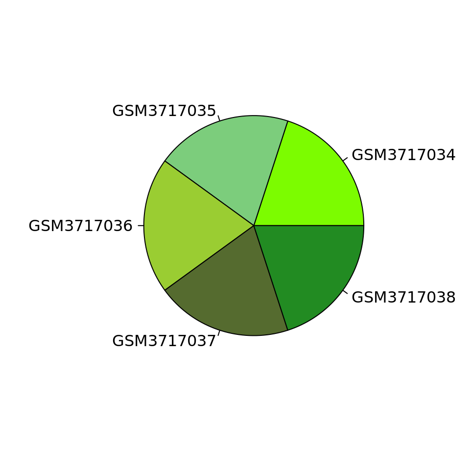

```r
graphics::pie(rep(1, nrow(sample_info)),
              col = sample_info$color,
              labels = sample_info$project_name)
```

We save it :

```r
saveRDS(sample_info, file = paste0(out_dir, "/", save_name, "_sample_info.rds"))
```

# Gene annotation

We processed the Takahashi datasets from the count matrices and not from the FASTQ files. In the count matrices, the Ensembl ID associated with gene names (symbols) is missing. We investigated the diverse versions of gene annotation (GTF) file for *Homo sapiens* to find the version corresponding the best to the gene names available in each dataset. Here, we download this annotation and save it as a dataframe. This dataframe will be stored in the `sobj@assays[["RNA"]]@meta.features` dataframe in all Seurat objects.

```r
url_hg38 = "https://ftp.ensembl.org/pub/release-74/gtf/homo_sapiens/Homo_sapiens.GRCh37.74.gtf.gz"
gene_corresp = aquarius::read_gtf(url_hg38, column_names = c("gene_id", "gene_name"))

dim(gene_corresp)
```

```
## [1] 63677     2
```

```r
head(gene_corresp)
```

```
##            gene_id  gene_name
## 1  ENSG00000223972    DDX11L1
## 17 ENSG00000227232     WASH7P
## 72 ENSG00000243485 MIR1302-11
## 78 ENSG00000237613    FAM138A
## 83 ENSG00000268020     OR4G4P
## 86 ENSG00000240361    OR4G11P
```

There are issues with some genes. They are not expressed/detected in the cells, but when we subset some cells in the Seurat object, these genes are remplaced by NA, which causes issues in the subsequent analyses. Therefore, we remove these genes.

```r
genes_pb = c("RP11-442N24__B.1", "RP11-99J16__A.2", "RP11-59D5__B.2", "RP11-445L13__B.3",
             "RP11-544L8__B.4", "XXyac-YX65C7_A.2", "XXyac-YX65C7_A.3", "RP11-524D16__A.3",
             "RP11-453F18__B.1", "Metazoa_SRP", "Y_RNA", "XX-DJ76P10__A.2", "5S_rRNA",
             "RP11-1157N2__B.2", "RP1-213J1P__B.1", "RP1-213J1P__B.2", "RP4-633O19__A.1",
             "RP4-754E20__A.5","CTA-280A3__B.2")

gene_corresp = gene_corresp %>%
  dplyr::filter(!(gene_name %in% genes_pb))

dim(gene_corresp)
```

```
## [1] 62710     2
```

We save it :

```r
saveRDS(gene_corresp, file = paste0(out_dir, "/", save_name, "_gene_corresp.rds"))
```